# Predicting Heart Disease Mortality

David Edelman

February 28, 2019

## Executive Summary

Heart disease is one of the leading causes of death in the United States. This document presents an analysis of county-by-county heart disease mortality rates (per 100,000 individuals) and uses various demographic statistics to build a model that predicts the heart disease mortality rate for that county

The given data set, containing known heart disease mortality rates, comprises 3198 observations, representing 1599 counties and data collected over two separate years. Both categorical and numeric data are present in the feature set, and after some initial data exploration, several other features were calculated. A predictive regression model was then created using select features in order to predict the heart disease mortality rate of 3080 county/year pairs, representing 1540 distinct counties.

While building and tuning the predictive model, the following features were deemed significant to the predictive power of the model:

### Area Information

- Area RUCC (Rural-Urban Continuum Codes) – classifies each county into one of 9 mutually exclusive categories that identifies (a) the population size, (b) the degree of urbanization and (c) proximity to a metropolitan area.
  - While the RUCC itself did now show any strong correlation to heart disease mortality rate, by combining one or more RUCC values into one of 5 groups based solely on population size, the data showed 3 population groups that skewed below the mean heart disease mortality rate and 1 that skewed above the mean.
  - Additionally, classifying the RUCC values into another calculated feature as “Metro” or “Non-Metro” showed the data being skewed below the mean for Metro and above the men for Non-Metro, adding an enhancement to the predictive model (data source: USDA Economic Research Service)

### Economic Factors

- Economic Typology – classifies each county into one of 6 mutually exclusive categories of economic dependence; two categories show a distribution skewed below the mean heart disease mortality rate and two categories are skewed above (source: USDA Economic Research Service).
- Percent of Civilian Labor – the annualized percent of the county’s population classified as civilian; analysis shows a moderate negative correlation to heart disease mortality rate (source: Bureau of Labor Statistics)

### Demographics

- Percent of non-Hispanic African Americans – analysis shows the strongest positive correlation among the 5 race/ethnicity groups (source: US Census Population Estimates)
- Percent of adults with less than a high-school diploma; percent of adults with a Bachelor’s degree (or higher) – the former shows a strong positive correlation, while the latter shows an equally strong negative correlation (source: US Census Population Estimates)

### Health Factors

- Air Pollution Particulate Matter – measured in µg/m3; the average concentration of fine particulate matter as measured over the year. Lower concentrations skewed below the population mean while higher concentrations skewed above (source: CDC WONDER).
- Percent of physical inactivity – percent of adult population that self-identifies as physically inactive (source: National Center for Chronic Disease Prevention and Health Promotion); physical inactivity showed a moderately strong correlation to heart disease mortality rate
- Percent of adult obesity; percent of diabetes; percent of adult smoking – each of the three factors individually showed a strong correlation with heart disease mortality rate, but with a thought experiment and some data transformation into combined factors, an even stronger correlation was found (sources NCCDPHP; NCCDPHP, Division of Diabetes Translation; Behavioral Risk Factor Surveillance System)
- Homicide, Motor Vehicle Death rates per 100,000 – two separate death rates (per 100,000 individuals); by scaling each rate to a logarithmic scale (base 10), a strong correlation to heart disease mortality rate was found (source: National Center for Health Statistics)

## Data Exploration and Initial Analysis

### Heart Disease Mortality Rate

#### Descriptive Statistics

Heart Disease Mortality Rate (herein shown with a unit of “deaths per 100,000 population”) in the given data set showed a mean of 279.4, median of 275.0, and standard deviation of 59.0 with a range of 109.0 – 512.0. A histogram with 40 equal bins (calculated based on the minimum and maximum values) and a box plot both show that heart disease mortality rate is approximately normal (skewed very slightly positive), with only approximately 10-15 outliers (values outside of the Inner Quartile Range of 237 – 317).

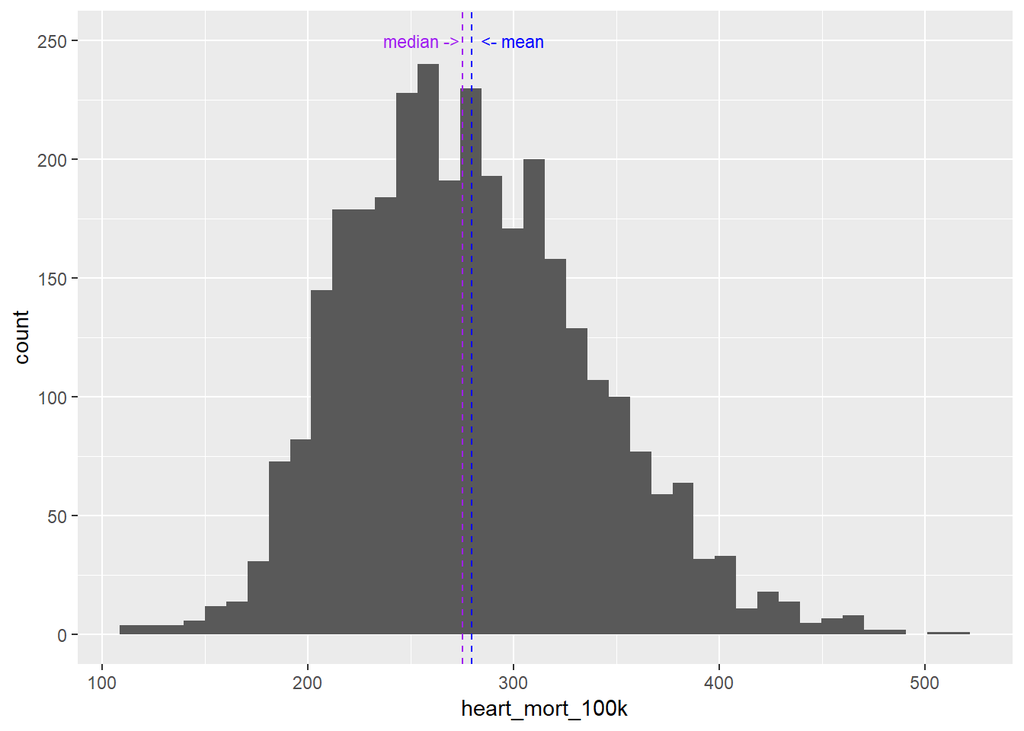

```r
#Historgram & boxplot
train_data %>% ggplot(aes(x=heart_disease_mortality_per_100k))+geom_histogram(bins=40)+
  xlab("heart_mort_100k")+
  geom_vline(linetype = "dashed", color = "purple", xintercept = hd_med)+
  geom_vline(linetype = "dashed", color = "blue", xintercept = hd_mean)+
  annotate("text", x=hd_mean+20, y=250, label="<- mean", size=3, color = "blue")+
  annotate("text", x=hd_med-20, y=250, label="median ->", size=3, color = "purple")
```

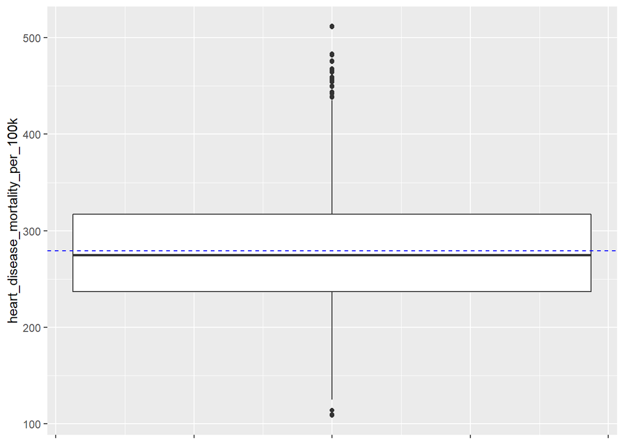

```r
train_data %>% ggplot(aes(y=heart_disease_mortality_per_100k))+geom_boxplot()+
  geom_hline(linetype = "dashed", color = "blue", yintercept = hd_mean)+
  theme(axis.text.x=element_blank())
```

#### Distributions Across Categorical Features

##### Economic Typology

The 6 economic typologies used by the USDA Economic Research Service to assign to each county are

*Farm-dependent* Federal/State government-dependent *Manufacturing-dependent* Mining-dependent *Non-specialized* Recreation

The typologies speak to the main type of industries of a particular county. So while we don’t have the specific industries in each county (knowing, intellectually, that certain industries have been linked in the past to specific conditions, including heart disease), we can use the typology as a good representative proxy for specific industries. To identify any potential relationship between typology and heart disease mortality, we use histograms and box plots to examine each typology for an abnormal or skewed distribution.

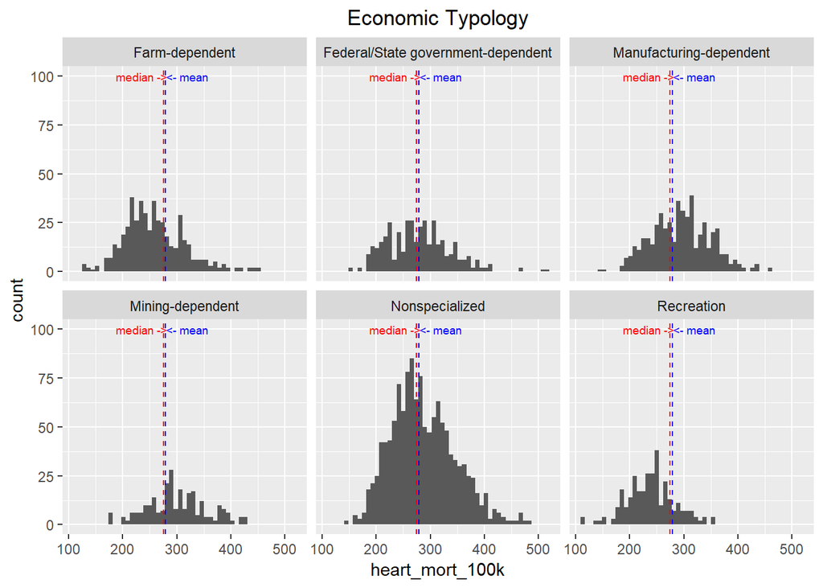

```r
#Histograms for economic type
train_data %>% ggplot(aes(x=heart_disease_mortality_per_100k))+
              xlab("heart_mort_100k")+
              geom_histogram(binwidth = (high_mort-low_mort)/50)+
              facet_wrap(~ econ__economic_typology, ncol = 3)+
              geom_vline(linetype="dashed", xintercept = hd_mean, color = "blue")+
              geom_vline(linetype="dashed", xintercept = hd_med, color = "red")+
              ggtitle("Economic Typology")+theme(plot.title = element_text(hjust=0.5))+
              annotate("text", x=hd_mean+40, y=100, label="<- mean", size=2.5, color = "blue")+
              annotate("text", x=hd_med-40, y=100, label="median ->", size=2.5, color = "red")
```

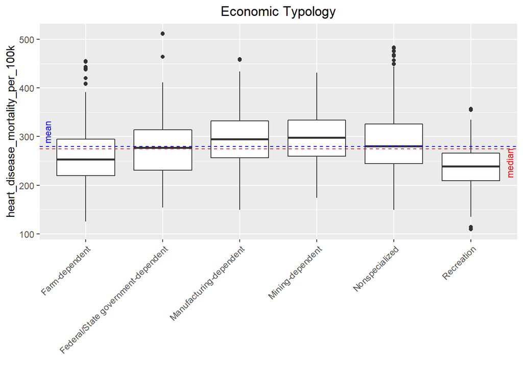

```r
#Box plot by economic type
train_data %>% ggplot(aes(x=econ__economic_typology, y=heart_disease_mortality_per_100k))+
        geom_boxplot() +
        geom_hline(linetype="dashed", yintercept = hd_mean, color = "blue")+xlab("")+
        geom_hline(linetype="dashed", yintercept = hd_med, color = "red")+
        theme(axis.text.x = element_text(angle = 45, hjust=1, vjust=1)) +
        ggtitle("Economic Typology")+theme(plot.title = element_text(hjust=0.5))+
        annotate("text", x=.5, y=hd_mean+30, label="mean", size=3, color = "blue", angle=90)+
        annotate("text", x=6.5, y=hd_med-30, label="median", size=3, color = "red", angle=90)
```

Due to heart disease mortality rates being distributed differently across the economic typologies, this feature is a good candidate for use in a predictive model.

##### Population Spread

The individual values for “Area_RUCC” have populations ranging from < 100 to > 600, and histograms show that many distributions do not appear to be approximately normal.

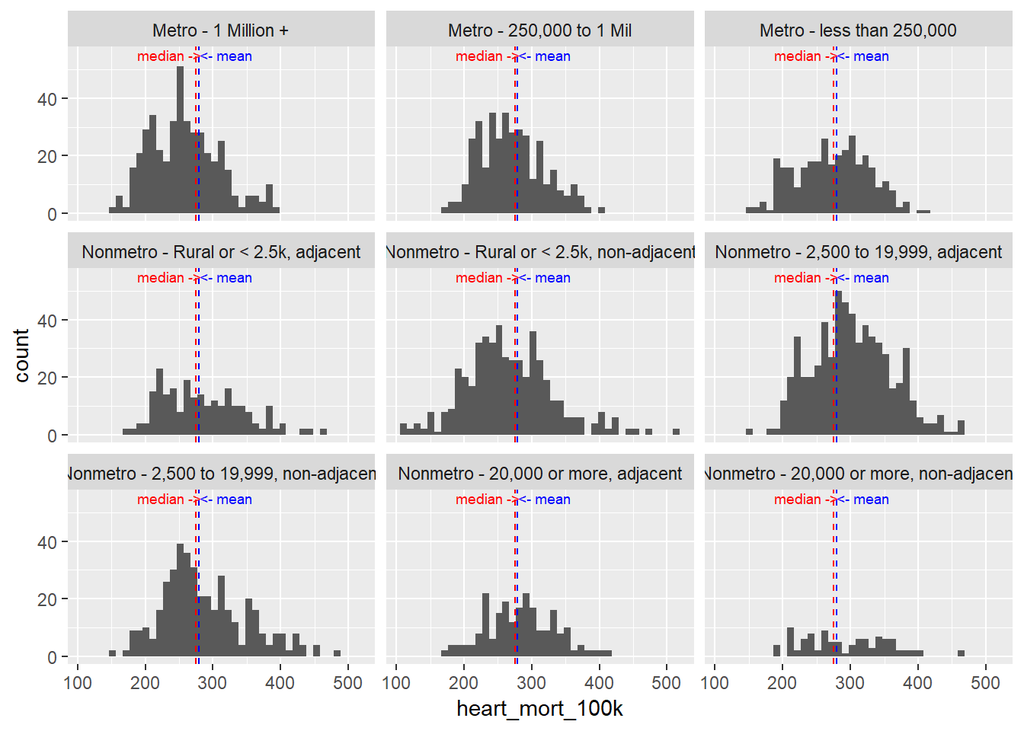

```r
plot <- ggplot(train_data,
               aes(x=heart_disease_mortality_per_100k))+xlab("heart_mort_100k")+
              geom_histogram(binwidth = (high_mort-low_mort)/40)
plot <- plot+facet_wrap(~ area__rucc, ncol = 3)
plot <- plot+geom_vline(linetype="dashed", xintercept = hd_mean, color = "blue")
plot <- plot+geom_vline(linetype="dashed", xintercept = hd_med, color = "red")
plot <- plot + annotate("text", x=hd_mean+40, y=55, label="<- mean", size=2.5, color = "blue")
plot <- plot + annotate("text", x=hd_med-40, y=55, label="median ->", size=2.5, color = "red")
plot
```

However, we can transform them into population groups as a proxy for Area_RUCC. The transformation is

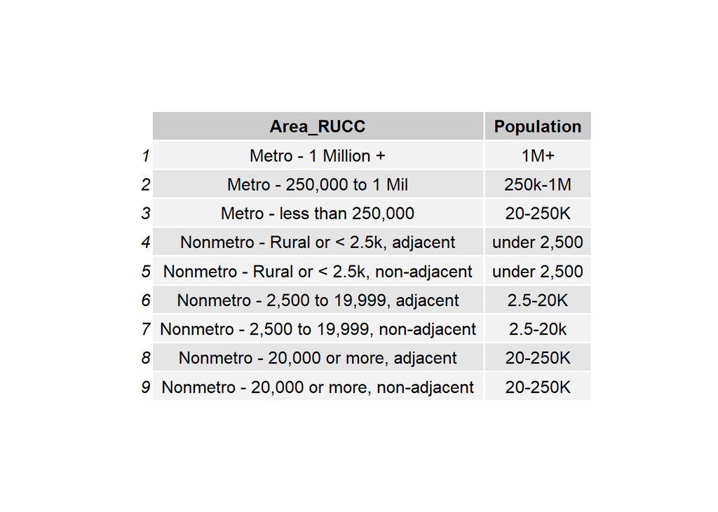

```r
train_data <- train_data %>%
  mutate(population = ifelse(like(train_data$area__rucc, "19,999"),"2.5-20k",
                      ifelse(like(train_data$area__rucc, "less than 2,500"), "under 2.5k",
                      ifelse(like(train_data$area__rucc, "20,000"), "20-250k",
                      ifelse(like(train_data$area__rucc, "fewer than 250,000"), "20-250k", ##same group
                      ifelse(like(train_data$area__rucc, "250,000"), "250k-1M",
                     "1M+"))))))
```

Looking at the histograms we now see a more even spread of data and more normal distributions.

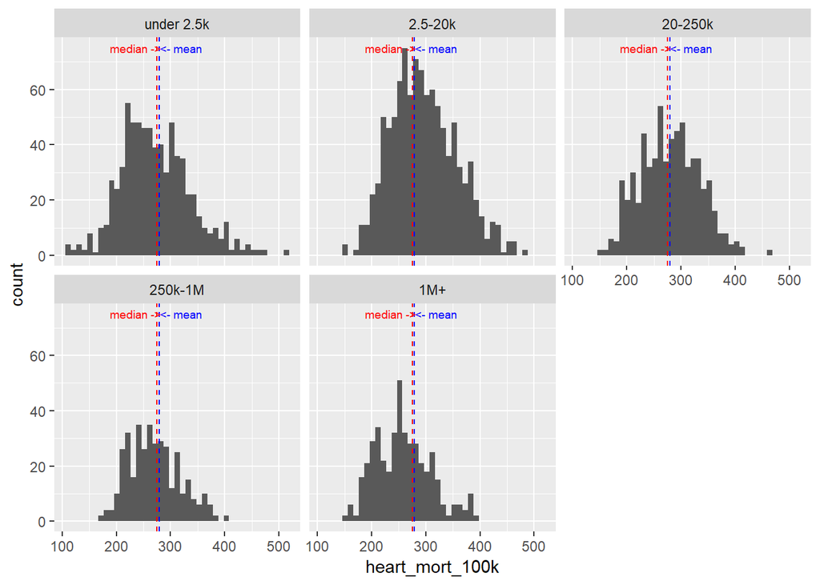

```r
#Histograms by population groups
plot <- ggplot(train_data,
               aes(x=heart_disease_mortality_per_100k))+xlab("heart_mort_100k")+
            geom_histogram(binwidth = (high_mort-low_mort)/40)
plot <- plot+facet_wrap(~ population, ncol = 3)
plot <- plot+geom_vline(linetype="dashed", xintercept = hd_mean, color = "blue")
plot <- plot+geom_vline(linetype="dashed", xintercept = hd_med, color = "red")
plot <- plot + annotate("text", x=hd_mean+40, y=75, label="<- mean", size=2.5, color = "blue")
plot <- plot + annotate("text", x=hd_med-40, y=75, label="median ->", size=2.5, color = "red")
plot
```

The “2.5-20K” group appears to be skewed somewhat positive, while the “1M+” group is skewed negative, even though the peak is below the population mean and median. Box plots show the distributions more cleanly.

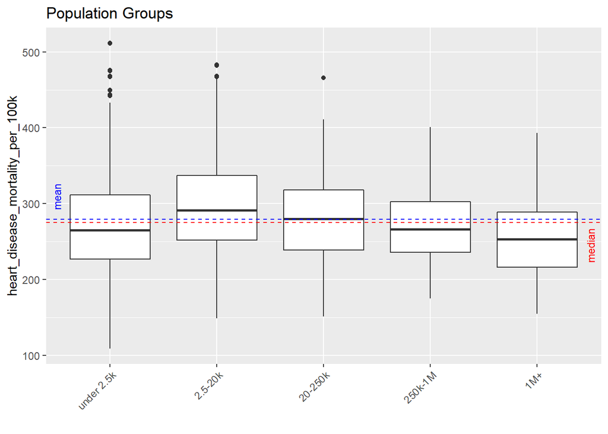

```r
#Box plot by population group
plot <- ggplot(train_data,
               aes(x=population, y=heart_disease_mortality_per_100k))+ xlab("")+
  geom_boxplot()+ geom_hline(linetype="dashed", yintercept = hd_mean, color = "blue")
plot <- plot+geom_hline(linetype="dashed", yintercept = hd_med, color = "red")
plot <- plot + theme(axis.text.x = element_text(angle = 45, hjust=1, vjust=1)) + ggtitle("Population Groups")
plot <- plot + annotate("text", x=.5, y=hd_mean+30, label="mean", size=3, color = "blue", angle=90)
plot <- plot + annotate("text", x=5.5, y=hd_med-30, label="median", size=3, color = "red", angle=90)
plot
```

Here we can more clearly see that the median for “under 2.5K”, “250K-1M” and “1M+” are all below the population mean and median. The group “2.5-20K” has a median well above the population mean and median, while the “20-250K” group median is only slightly higher than the population.

With population groups showing a different distribution for heart mortality rates, this calculated feature is another good candidate for use in a predictive model.

The analysis went one step further and grouped the RUCC values based on whether or not the county was considered to be a metropolitan area or not. Based solely on the first word in the RUCC category title (see Table 2), each county was classified as either “Metro” or “Non-Metro”.

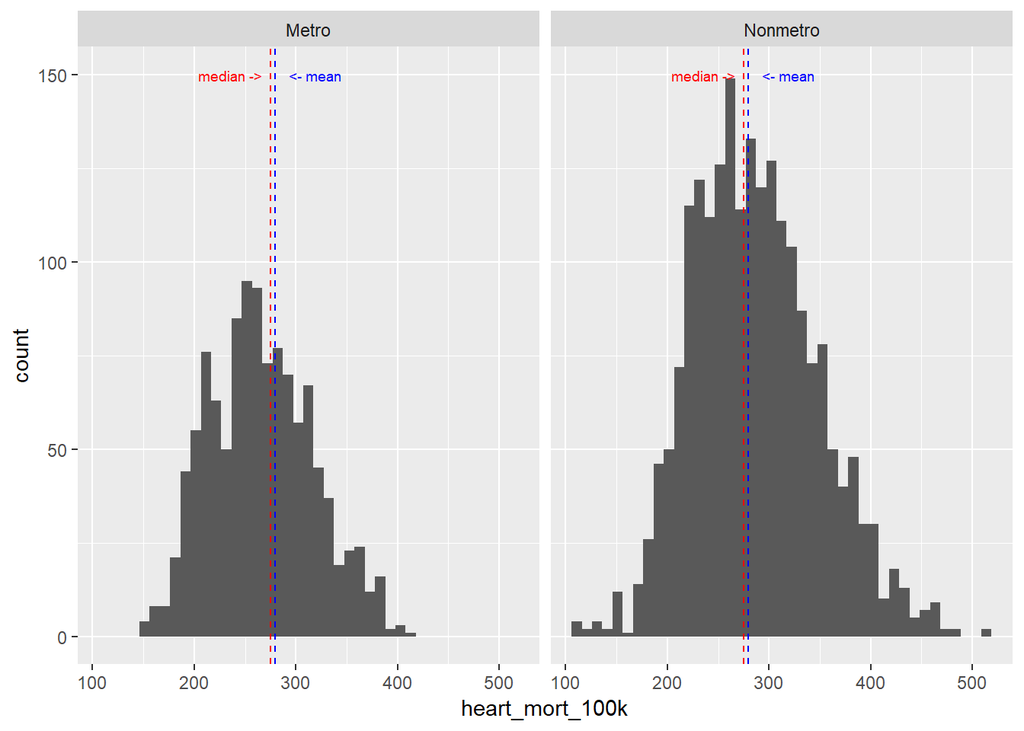

```r
#Histograms by metro type
plot <- ggplot(train_data,
               aes(x=heart_disease_mortality_per_100k))+xlab("heart_mort_100k")+
  geom_histogram(binwidth = (high_mort-low_mort)/40)
plot <- plot+facet_wrap(~ metro, ncol = 3)
plot <- plot+geom_vline(linetype="dashed", xintercept = hd_mean, color = "blue")
plot <- plot+geom_vline(linetype="dashed", xintercept = hd_med, color = "red")
plot <- plot + annotate("text", x=hd_mean+40, y=150, label="<- mean", size=2.5, color = "blue")
plot <- plot + annotate("text", x=hd_med-40, y=150, label="median ->", size=2.5, color = "red")
plot
```

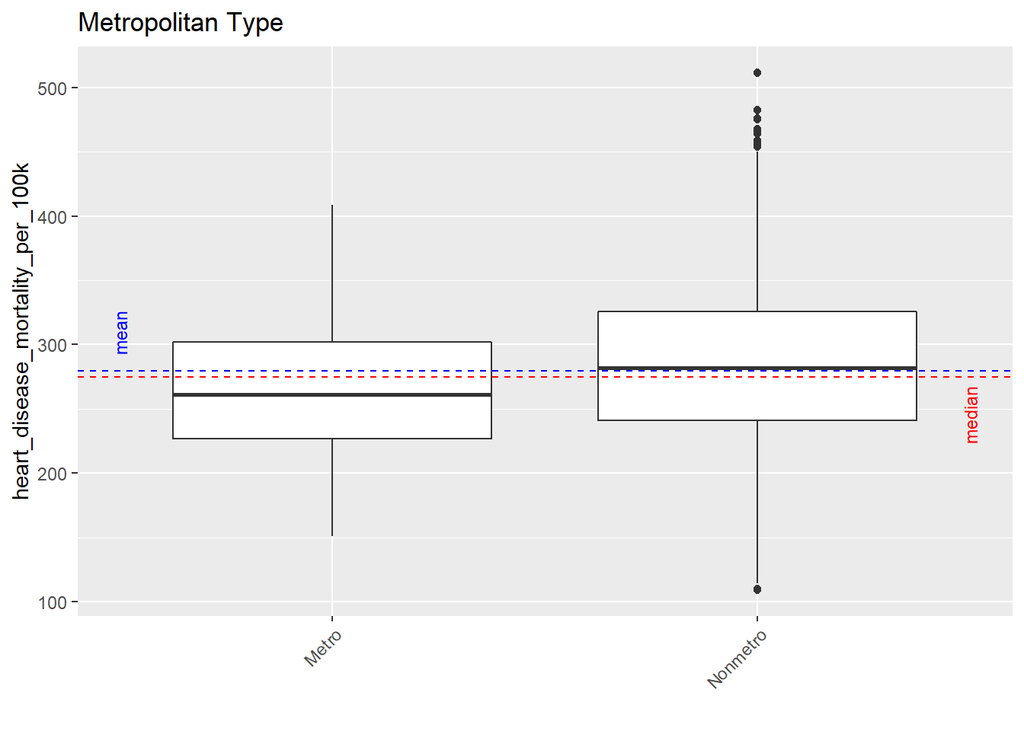

```r
#Box plot by metro_type
plot <- ggplot(train_data,
               aes(x=metro, y=heart_disease_mortality_per_100k))+xlab("")+
  geom_boxplot()+ geom_hline(linetype="dashed", yintercept = hd_mean, color = "blue")
plot <- plot+geom_hline(linetype="dashed", yintercept = hd_med, color = "red")
plot <- plot + theme(axis.text.x = element_text(angle = 45, hjust=1, vjust=1)) + ggtitle("Metropolitan Type")
plot <- plot + annotate("text", x=.5, y=hd_mean+30, label="mean", size=3, color = "blue", angle=90)
plot <- plot + annotate("text", x=2.5, y=hd_med-30, label="median", size=3, color = "red", angle=90)
plot
```

The box plots clearly show that metropolitan areas have a lower median than the population, while non-metropolitan areas skew higher than the population as a whole.

##### Air Pollution

Ambient air pollution for the county is presented in the data set as a measure of the concentration of fine particulate matter, as measured in µg/m<sup>3</sup>. These figures were presented as positive integers, so as a feature of the data set it is more akin to a categorical variable. The initial spread of values showed a large discrepancy in population size, especially in the min and max regions (A), so values were grouped into a smaller number of populations that were closer in size (B)

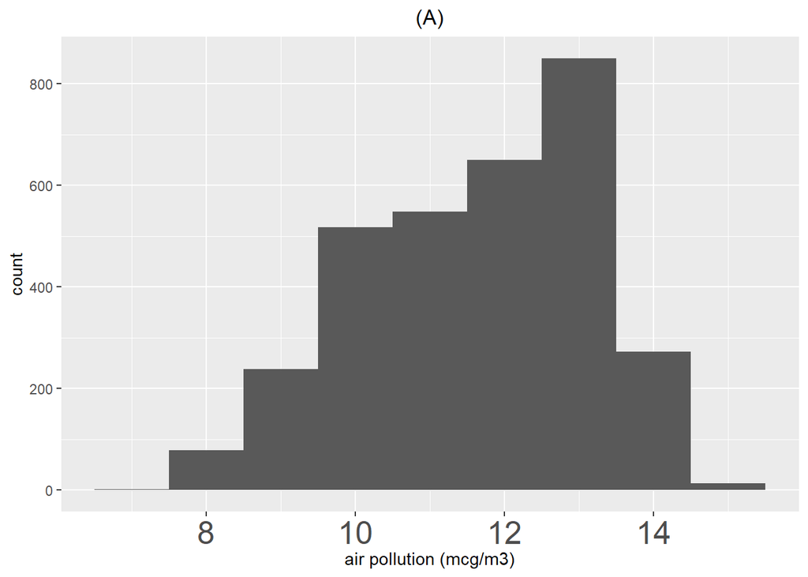

```r
#Histogram for air pollution original
plot <- ggplot(subset(train_data, !is.na(health__air_pollution_particulate_matter)),
               aes(x=health__air_pollution_particulate_matter))+
  geom_histogram(binwidth=1) + xlab("air pollution (mcg/m3)")
plot <- plot + theme(axis.text.x = element_text(size=20))+
  ggtitle("(A)")+theme(plot.title = element_text(hjust=0.5))
plot
```

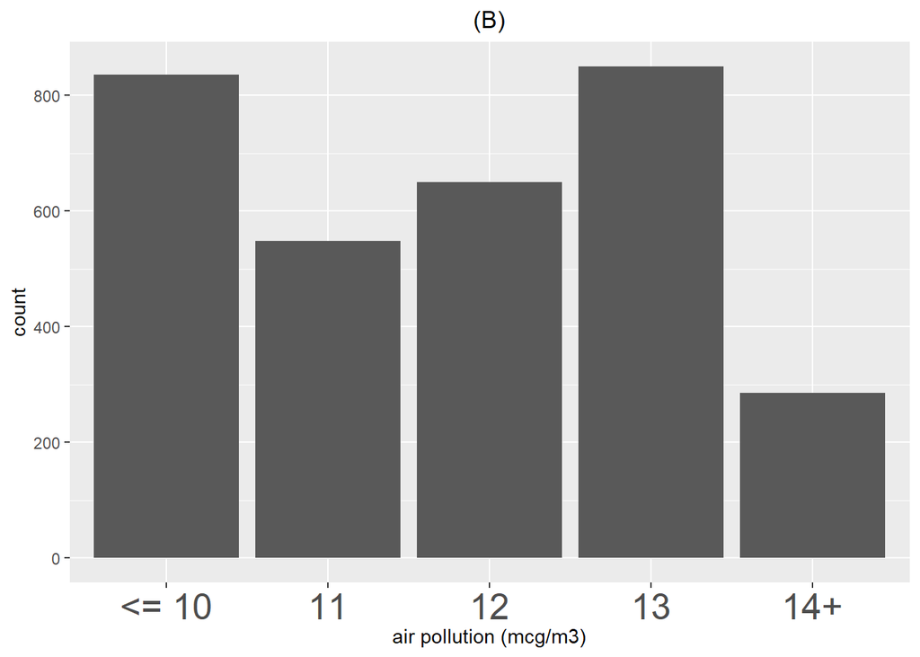

```r
#Histogram for air pollution regrouped
cut_labels <- c("<= 10", "11", "12", "13", "14+")
cut_levels <- c(0, 10.9, 11.9, 12.9, 13.9, 100)

train_data$air_pollution <- cut(train_data$health__air_pollution_particulate_matter, cut_levels)
levels(train_data$air_pollution) <- cut_labels

plot <- ggplot(subset(train_data, !is.na(air_pollution)),
               aes(x=air_pollution))+
  geom_bar() + xlab("air pollution (mcg/m3)")
plot <- plot + theme(axis.text.x = element_text(size=20))+
  ggtitle("(B)")+theme(plot.title = element_text(hjust=0.5))
plot
```

Using the new groups, histograms and boxplots show the spreads to be approximately normal, with some groups skewing below the population mean and some above. The group with 12 µg/m<sup>3</sup> shows a mean just at the population mean, with a median slightly lower.

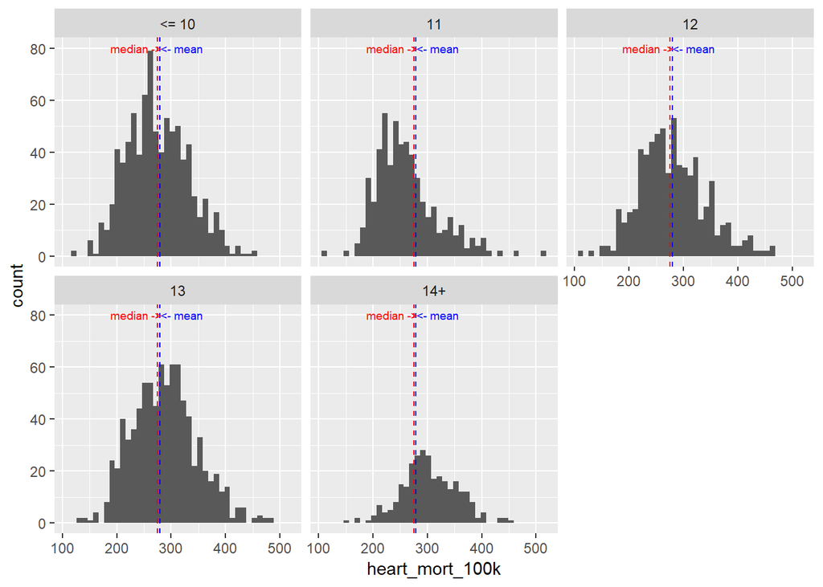

```r
#Histograms by air pollution
plot <- ggplot(subset(train_data, !is.na(air_pollution)),
               aes(x=heart_disease_mortality_per_100k))+xlab("heart_mort_100k")+
  geom_histogram(binwidth = (high_mort-low_mort)/40)
plot <- plot+facet_wrap(~ air_pollution, drop=TRUE, ncol = 3)
plot <- plot+geom_vline(linetype="dashed", xintercept = hd_mean, color = "blue")
plot <- plot+geom_vline(linetype="dashed", xintercept = hd_med, color = "red")
plot <- plot + annotate("text", x=hd_mean+40, y=80, label="<- mean", size=2.5, color = "blue")
plot <- plot + annotate("text", x=hd_med-40, y=80, label="median ->", size=2.5, color = "red")
plot
```

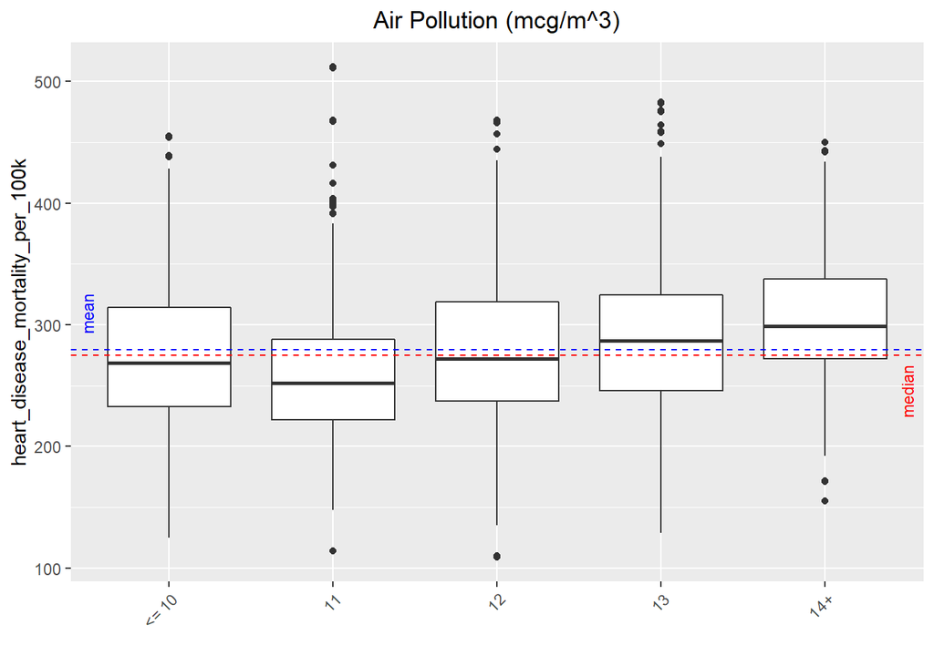

```r
#Box plot by air_pollution
plot <- ggplot(subset(train_data, !is.na(air_pollution)),
               aes(x=air_pollution, y=heart_disease_mortality_per_100k))+xlab("")+
  geom_boxplot()+ geom_hline(linetype="dashed", yintercept = hd_mean, color = "blue")
plot <- plot+geom_hline(linetype="dashed", yintercept = hd_med, color = "red")
plot <- plot + theme(axis.text.x = element_text(angle = 45, hjust=1, vjust=1)) + ggtitle("Air Pollution (mcg/m^3)")+theme(plot.title = element_text(hjust=0.5))
plot <- plot + annotate("text", x=.5, y=hd_mean+30, label="mean", size=3, color = "blue", angle=90)
plot <- plot + annotate("text", x=5.5, y=hd_med-30, label="median", size=3, color = "red", angle=90)
plot
```

#### Correlation Between Numeric Features and Heart Disease Mortality

(note: all correlation calculations in this analysis are performed after data records with missing values for the feature in questions are removed)

##### Economic Factors

The remaining economic factors in the dataset (after already looking at typology) are numeric, so a correlation analysis is done to determine if any of these are candidates for use in a predictive model. * % Civilian Labor * % Unemployment * % Uninsured Adults * % Uninsured Children

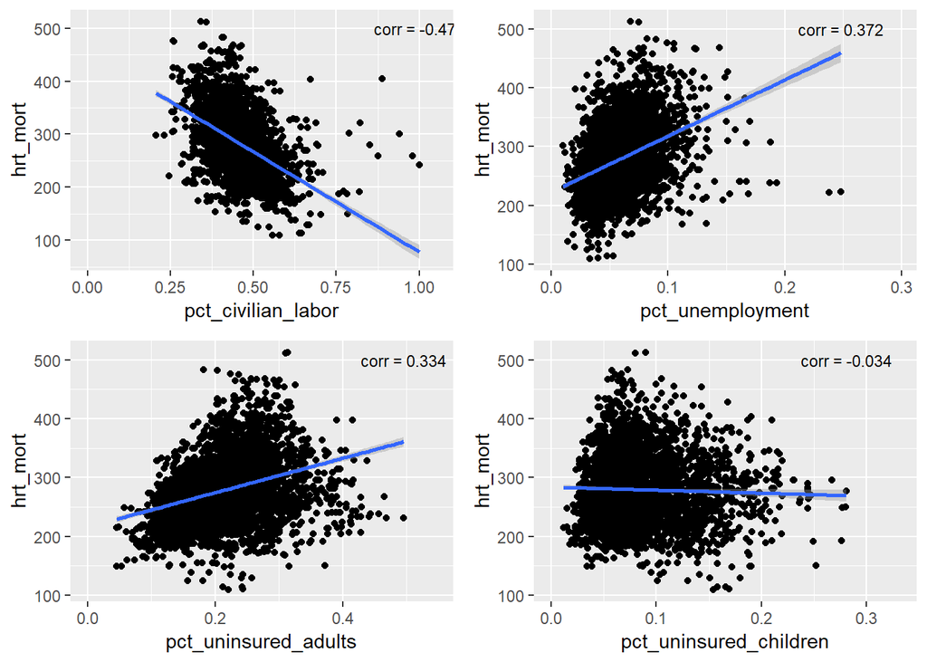

```r
#Correlation among econ stats
cname <- colnames(train_data)
cname <- cname[like(cname,"econ__pct")]

par(mfrow=c(2,2))

p = list()

for (i in 1:length(cname)) {

  #Determine correlation with default method
  cor <- round(cor(data.frame(train_data$heart_disease_mortality_per_100k,
                              train_data[,cname[i]]),
                   use="complete.obs")[1,2],3)
  cor <- paste("corr =", as.character(cor))

  #Plot econ factor vs mortality
    dplot <- ggplot(train_data,
                  aes_string(y="heart_disease_mortality_per_100k",
                             x=cname[i]))+
    ylab("hrt_mort")+
    xlab(substr(cname[i], 7, 100))+
    xlim(0,max(train_data[cname[i]], na.rm=TRUE)+.05)

  p[[i]] <- dplot+geom_point(na.rm=TRUE)+
    geom_smooth(method="lm", se=TRUE, na.rm=TRUE)+
    annotate("text", x=max(train_data[cname[i]],na.rm=TRUE), y=500, label= cor, size=3)
}

do.call(grid.arrange, p)
```

As seen in Figure 8, “Percent of Civilian Labor” shows a moderate negative correlation with heart disease mortality (despite the number of outliers appearing to be greater than the other factors) and is a good candidate for use in a predictive model. The remaining factors do not show a strong enough correlation ( >= 0.45) to be considered good candidates.

##### Demographics

The dataset contains 12 demographic features that are reported as percentages of the population. A correlation analysis of those features in a similar manner to the economic factors. (NOTE: there are 2 numeric features that are represented as rates per 1000 people, and act more like categorical features as they are distinct whole numbers; a cursory exploration of these two factors was performed, but nothing of interest resulted from the exploration)

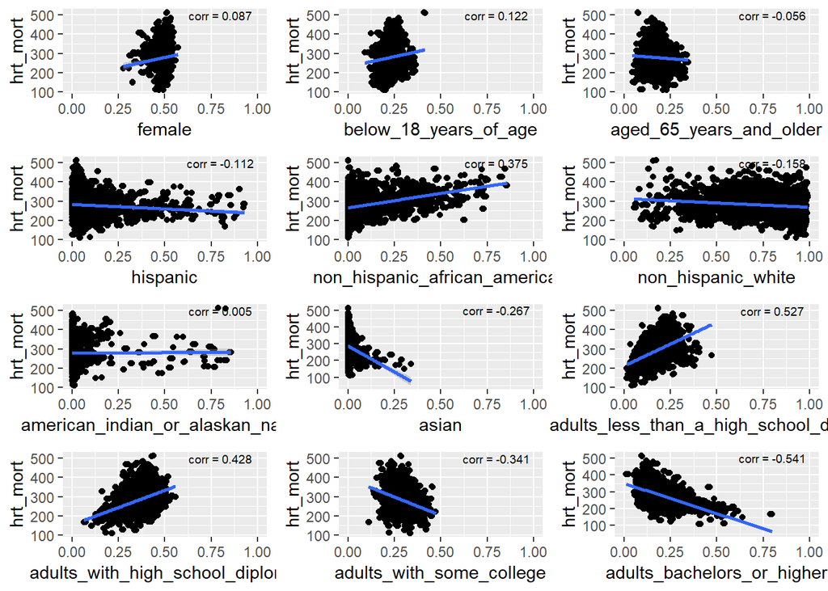

```r
#Correlation among demo stats
cname <- colnames(train_data)
cname <- cname[like(cname,"demo_")]
cname <- cname[!like(cname, "_1k")]

par(mfrow=c(3,4))

p = list()

for (i in 1:length(cname)) {
  #Determine correlation with default method
    cor <- round(cor(data.frame(train_data$heart_disease_mortality_per_100k,
                              train_data[,cname[i]]),
                   use="complete.obs")[1,2],3)
  cor <- paste("corr =", as.character(cor))

  #Plot demo vs mortality
  dplot <- ggplot(train_data,
                  aes_string(y="heart_disease_mortality_per_100k",
                             x=cname[i]))+
                    ylab("hrt_mort")+
                    xlab(substr(cname[i], 11, 100)) #+
                    #xlim(0,1)

  p[[i]] <- dplot+geom_point(na.rm=TRUE)+
    geom_smooth(method="lm", se=TRUE, na.rm=TRUE)+
    annotate("text", x=.8, y=500, label= cor, size=2.5)+xlim(0, 1)
}

do.call(grid.arrange, p)
```